# Weekly squad report

Weekly squad report Week ending Wednesday 15 September 2021 · All players

42 Players trained

77,350 AU Squad load this week down 18% on last week

0.99 Average ACWR Safe range 0.8–1.5

4 Speak to first plus 14 to monitor

79% Wellness reporting 1 players sent none

**This week:** squad load was down 18% on last week. **4** players have both a load and a wellness flag and should be spoken to first; **14** more need monitoring.

## Players to review

Sorted by priority. “Speak to first” means load outside the safe range *and* wellness more than 0.5 SD below the player’s normal.

| Player | Team | Weekly load | vs last week | ACWR | Wellness (7d) | Status | Why flagged |
| --- | --- | --- | --- | --- | --- | --- | --- |
| B-29c5 | Team B | 830 | – | 1.75 | −0.61 | Speak to first | ACWR above 1.5 · Low wellness |
| B-2f23 | Team B | 1,350 | −38% | 0.65 | −0.60 | Speak to first | ACWR below 0.8 · Low wellness |
| B-4405 | Team B | 810 | −32% | 0.48 | −0.52 | Speak to first | ACWR below 0.8 · Low wellness |
| A-4051 | Team A | 900 | −67% | 0.34 | −0.56 | Speak to first | ACWR below 0.8 · Low wellness |
| B-08e3 | Team B | 2,070 | – | 3.58 | −0.08 | Monitor | ACWR above 1.5 |
| A-2d44 | Team A | 1,515 | +159% | 2.66 | −0.01 | Monitor | ACWR above 1.5 |
| A-74af | Team A | 1,320 | −26% | 0.92 | −0.66 | Monitor | Low wellness |
| A-3586 | Team A | 2,230 | −25% | 0.78 | 0.02 | Monitor | ACWR below 0.8 |
| B-afc1 | Team B | 1,670 | +28% | 0.78 | 0.11 | Monitor | ACWR below 0.8 |
| A-9670 | Team A | 1,520 | −23% | 0.77 | −0.32 | Monitor | ACWR below 0.8 |
| A-82a0 | Team A | 960 | +12% | 0.76 | 0.18 | Monitor | ACWR below 0.8 |
| A-c91a | Team A | 1,160 | −60% | 0.76 | −0.22 | Monitor | ACWR below 0.8 |
| B-7895 | Team B | 870 | −55% | 0.49 | 0.10 | Monitor | ACWR below 0.8 |
| B-f676 | Team B | 680 | −76% | 0.49 | −0.48 | Monitor | ACWR below 0.8 |
| A-7a0f | Team A | 1,290 | −61% | 0.44 | −0.14 | Monitor | ACWR below 0.8 |
| B-6d56 | Team B | 420 | −67% | 0.35 | −0.04 | Monitor | ACWR below 0.8 |
| B-ab5e | Team B | 300 | −79% | 0.27 | 0.96 | Monitor | ACWR below 0.8 |
| B-5a92 | Team B | 180 | −84% | 0.18 | 0.12 | Monitor | ACWR below 0.8 |

## Load vs wellness

Each dot is a player. Shaded areas are outside the safe range.

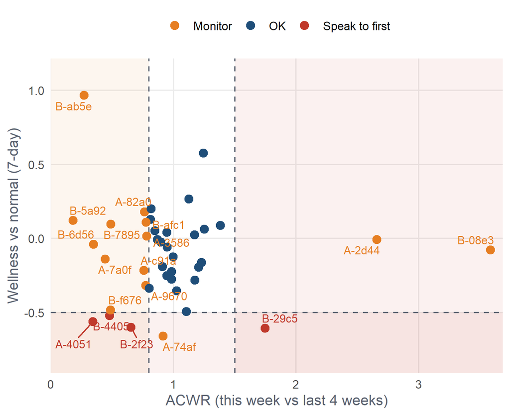

## Squad load, last 8 weeks

Total weekly load by team. This week is highlighted.

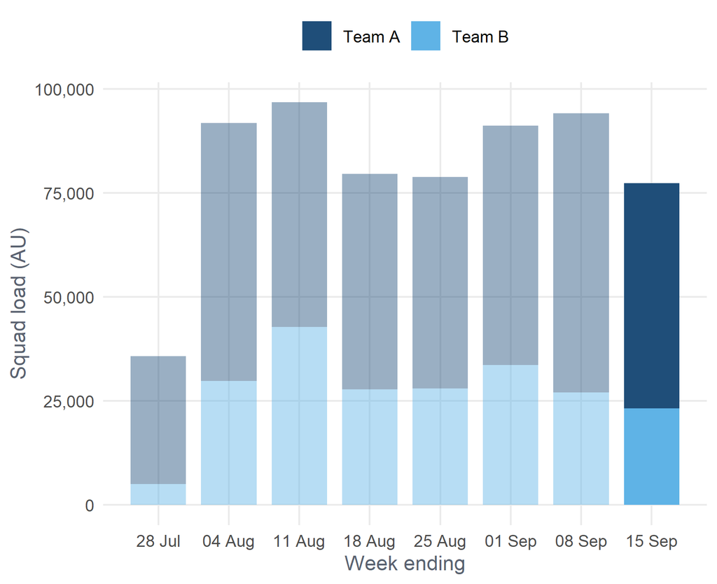

## Last four weeks for flagged players

Daily training load. The week under review is shaded.

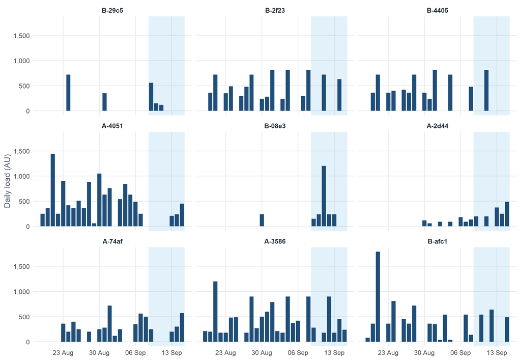

## Wellness reporting

79% of possible reports were completed this week. Players who sent none: **A-c4cc**.

**NoteFull squad this week (click to expand)**

| Player | Team | Weekly load | ACWR | Monotony | Wellness (7d) | Reports | Status |
| --- | --- | --- | --- | --- | --- | --- | --- |
| B-08e3 | Team B | 2,070 | 3.58 | 0.77 | −0.08 | 7 | Monitor |
| A-2d44 | Team A | 1,515 | 2.66 | 1.30 | −0.01 | 6 | Monitor |
| B-29c5 | Team B | 830 | 1.75 | 0.62 | −0.61 | 6 | Speak to first |
| A-560c | Team A | 2,650 | 1.38 | 1.74 | 0.09 | 6 | OK |
| A-c4cc | Team A | 2,540 | 1.37 | 1.08 | – | 0 | OK |
| B-4d54 | Team B | 1,920 | 1.25 | 1.30 | 0.06 | 5 | OK |
| A-3e5f | Team A | 2,590 | 1.24 | 1.18 | 0.58 | 6 | OK |
| B-e432 | Team B | 2,340 | 1.23 | 1.08 | −0.16 | 3 | OK |
| A-5cd7 | Team A | 4,140 | 1.21 | 1.77 | −0.20 | 7 | OK |
| A-bcc0 | Team A | 3,400 | 1.17 | 1.73 | −0.28 | 6 | OK |
| A-affd | Team A | 2,650 | 1.17 | 1.10 | 0.02 | 7 | OK |
| B-4b1e | Team B | 360 | 1.13 | 0.41 | 0.27 | 2 | OK |
| A-5a5b | Team A | 2,810 | 1.11 | 1.40 | −0.49 | 6 | OK |
| A-0362 | Team A | 1,970 | 1.02 | 1.24 | −0.35 | 7 | OK |
| B-7d41 | Team B | 4,020 | 1.00 | 1.40 | −0.13 | 7 | OK |
| B-ab69 | Team B | 2,200 | 0.99 | 1.05 | −0.22 | 3 | OK |
| A-78f2 | Team A | 2,520 | 0.98 | 1.45 | −0.28 | 6 | OK |
| A-b58a | Team A | 2,290 | 0.95 | 1.08 | −0.06 | 7 | OK |
| A-ecdb | Team A | 2,345 | 0.95 | 1.39 | 0.04 | 7 | OK |
| A-f205 | Team A | 2,500 | 0.95 | 1.09 | −0.25 | 7 | OK |
| A-74af | Team A | 1,320 | 0.92 | 0.96 | −0.66 | 5 | Monitor |
| B-70b7 | Team B | 1,590 | 0.91 | 0.87 | −0.19 | 7 | OK |
| A-32fe | Team A | 1,630 | 0.90 | 0.66 | −0.03 | 7 | OK |
| A-5a3b | Team A | 2,730 | 0.87 | 1.67 | −0.01 | 7 | OK |
| A-af71 | Team A | 2,340 | 0.85 | 1.68 | 0.05 | 7 | OK |
| B-48bf | Team B | 1,650 | 0.82 | 1.03 | 0.20 | 7 | OK |
| A-7059 | Team A | 1,640 | 0.81 | 1.24 | 0.13 | 5 | OK |
| A-e920 | Team A | 2,450 | 0.80 | 1.14 | −0.34 | 6 | OK |
| A-3586 | Team A | 2,230 | 0.78 | 1.19 | 0.02 | 7 | Monitor |
| B-afc1 | Team B | 1,670 | 0.78 | 0.86 | 0.11 | 4 | Monitor |
| A-9670 | Team A | 1,520 | 0.77 | 2.00 | −0.32 | 7 | Monitor |
| A-82a0 | Team A | 960 | 0.76 | 0.83 | 0.18 | 7 | Monitor |
| A-c91a | Team A | 1,160 | 0.76 | 0.57 | −0.22 | 4 | Monitor |
| B-2f23 | Team B | 1,350 | 0.65 | 0.63 | −0.60 | 3 | Speak to first |
| B-7895 | Team B | 870 | 0.49 | 0.85 | 0.10 | 5 | Monitor |
| B-f676 | Team B | 680 | 0.49 | 0.83 | −0.48 | 7 | Monitor |
| B-4405 | Team B | 810 | 0.48 | 0.41 | −0.52 | 2 | Speak to first |
| A-7a0f | Team A | 1,290 | 0.44 | 0.53 | −0.14 | 3 | Monitor |
| B-6d56 | Team B | 420 | 0.35 | 0.41 | −0.04 | 6 | Monitor |
| A-4051 | Team A | 900 | 0.34 | 0.73 | −0.56 | 7 | Speak to first |
| B-ab5e | Team B | 300 | 0.27 | 0.41 | 0.96 | 3 | Monitor |
| B-5a92 | Team B | 180 | 0.18 | 0.41 | 0.12 | 6 | Monitor |

**How flags work:** ACWR = acute (7-day) ÷ chronic (28-day) load, with the safe range taken as 0.8–1.5. Wellness (7d) = average of fatigue, soreness, sleep quality and stress z-scores over the week, where 0 is the player’s own normal. Monotony = mean ÷ SD of daily load over the week. Flags prompt a conversation; they are not a diagnosis.  
Data: SoccerMon (Midoglu et al., CC BY 4.0). Report generated 11 November 2026 with R and Quarto by Will Page.